# Computational Techniques 2

## Integration

- Economic objectives often include an integral or expectation that must be evaluated numerically.
- This section moves from deterministic rules to sampling methods as the dimension of the problem increases.
- The examples follow Judd’s notes on [numerical integration](https://kenjudd.org/wp-content/uploads/2020/08/Lecture_14_1_Numerical-Integration.pdf) and [Monte Carlo methods](https://kenjudd.org/wp-content/uploads/2020/08/Lecture_14_2_Monte-Carlo-and-Simulation-Methods.pdf).

### Type of Approach

- Numerical integration methods first divide into deterministic rules and sampling methods.

```
%%{init: {"flowchart": {"nodeSpacing": 18, "rankSpacing": 25}, "themeVariables": {"fontSize": "14px"}}}%%
flowchart LR
    A["Integration"] --> B["Deterministic"]
    A --> C["Sampling"]
    B --> D["Trapezoid"]
    B --> E["Gaussian"]
    B --> F["QuadGK"]
    C --> G["Monte Carlo"]
    C --> H["Quasi-Monte Carlo"]
```

- Start with QuadGK for a general one-dimensional integral.
- Use Gaussian quadrature when the domain or probability distribution is known and the same integral is evaluated repeatedly.
- Move to Monte Carlo or quasi-Monte Carlo when the number of shocks or dimensions makes deterministic rules too expensive.

### Example of Integration

- The method will change throughout the section, but the quantity being approximated will remain the same.
- **Overview:** A common benchmark makes the approximation error from each method easy to interpret.
- Let $Z$ follow a standard normal distribution and define

$$Z\sim N(0,1),
\qquad
Q(\theta)
=
E\left[\exp(\theta Z)\right].$$

- This expectation has the analytical value

$$Q(\theta)=\exp\left(\frac{\theta^2}{2}\right).$$

- We use $\theta=0.75$ to compare the numerical methods.

```julia
using Random, Statistics, Distributions, LinearAlgebra
using QuadGK, FastGaussQuadrature
using QuasiMonteCarlo
using ForwardDiff
using Zygote
using DataFrames
using Plots
```

```julia
standard_normal = Normal()
evaluation_parameter = 0.75

expectation_integrand(θ, z) = exp(θ * z)
normal_weighted_integrand(θ, z) =
    exp(θ * z - z^2 / 2) / sqrt(2π)
exact_expectation(θ) = exp(θ^2 / 2)

@show evaluation_parameter
@show exact_expectation(evaluation_parameter)
nothing
```

```
evaluation_parameter = 0.75
exact_expectation(evaluation_parameter) = 1.3247847587288655
```

### Deterministic Methods

- The running example is a continuous integral, but a computer must reduce it to finitely many function evaluations.
- **Overview:** Numerical integration replaces an area by a weighted sum.
- **Idea:** Evaluate the function at selected nodes and combine those values with numerical weights.
- Numerical integration replaces an area by a weighted sum:

$$\int_a^b f(x)\,dx
\approx
\sum_{i=1}^n w_i f(x_i).$$

#### Trapezoid Rule

- The trapezoid rule gives the simplest geometric illustration: it integrates a piecewise-linear approximation to $f$.

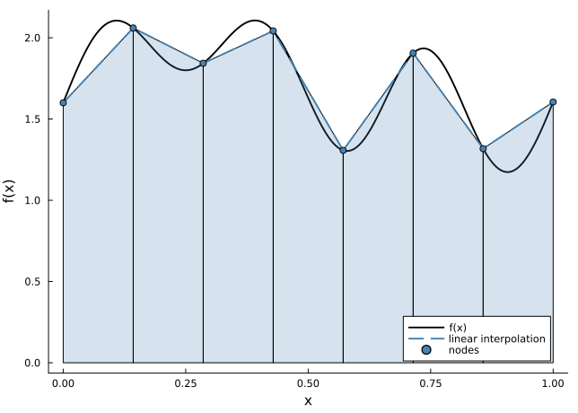

Figure 1: The trapezoid rule integrates the piecewise-linear interpolant.

#### Gaussian Quadrature

- The trapezoid rule uses evenly spaced nodes. Gaussian quadrature instead chooses nodes and weights that are efficient for a known domain or probability weight.
- **Overview:** Gaussian quadrature chooses both nodes and weights to extract as much accuracy as possible from a fixed number of evaluations.
- **Idea:** Start from a weighted integral:

$$I(f)=\int_D \rho(x)f(x)\,dx.$$

1. Fix the domain $D$ and weight function $\rho$.
2. Construct the degree-$n$ polynomial $\pi_n$ that is orthogonal under $\rho$.
3. Use the $n$ roots of $\pi_n$ as the nodes $x_i$.
4. Set $w_i=\int_D\rho(x)\ell_i(x)\,dx$, where $\ell_i(x_j)=\mathbf{1}\{i=j\}$, and evaluate $\sum_{i=1}^n w_i f(x_i)$.
- The resulting rule is exact for every polynomial of degree at most $2n-1$.
- For a general integrand, accuracy depends on how well a polynomial of this degree approximates it; increase the number of nodes or use adaptive quadrature when the integrand is irregular.
- The nodes and weights depend on $D$ and $\rho$, not on the user’s integrand.
- [`FastGaussQuadrature.jl`](https://juliaapproximation.github.io/FastGaussQuadrature.jl/stable/) supplies the rules; the user supplies the economic integrand.

**Example: Two-Point Gauss–Legendre**

- Symmetry gives nodes $-a,a$ with a common weight $w$.
- Matching the integrals of $1$ and $x^2$ gives $2w=2$ and $2wa^2=2/3$, so $w=1$ and $a=1/\sqrt{3}$.
- Therefore, $\int_{-1}^{1}f(x)\,dx\approx f(-1/\sqrt{3})+f(1/\sqrt{3})$, which is exact through degree three.

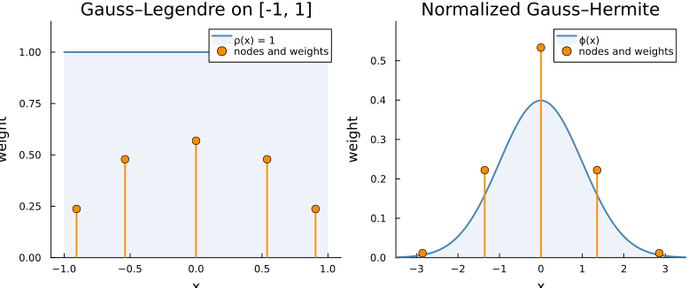

Figure 2: The background curve is the integral’s weight function. Each stem marks a node, and its height is the corresponding quadrature weight.

| Rule | Weighted integral | Nodes | Typical use |
| --- | --- | --- | --- |
| Gauss–Legendre | $\int_{-1}^{1}f(x)\,dx$ | Roots of a Legendre polynomial | Bounded interval |
| Gauss–Hermite | $\int_{-\infty}^{\infty}e^{-x^2}f(x)\,dx$ | Roots of a Hermite polynomial | Classical Hermite-weighted integral |
| Gauss–Hermite with `normalize=true` | $\int_{-\infty}^{\infty}\phi(x)f(x)\,dx$ | Hermite nodes rescaled for $\phi$ | Standard normal expectation |

**What normalize=true changes**

- By default, `gausshermite` returns nodes $x_i$ and weights $w_i$ for

$$\int_{-\infty}^{\infty}e^{-x^2}f(x)\,dx
\approx
\sum_{i=1}^n w_i f(x_i),
\qquad
\sum_{i=1}^n w_i=\sqrt{\pi}.$$

- Setting `normalize=true` applies $z_i=\sqrt{2}x_i$ and $\widetilde w_i=w_i/\sqrt{\pi}$, so

$$E[f(Z)]
=
\int_{-\infty}^{\infty}\phi(z)f(z)\,dz
\approx
\sum_{i=1}^n \widetilde w_i f(z_i),
\qquad
\sum_{i=1}^n \widetilde w_i=1.$$

- Normalization changes the target weight and coordinate scale, not the order of accuracy of the rule.

**How the package computes the rule**

- FastGaussQuadrature finds the polynomial roots with Newton’s method and a recurrence, with asymptotic formulas for large rules.
- It computes weights from those roots and derivatives; it does not optimize them separately for each integrand.
- The following code maps Gauss–Legendre nodes to a bounded interval and uses normalized Gauss–Hermite nodes for the running normal expectation.

```julia
legendre_nodes, legendre_weights = gausslegendre(5)
mapped_nodes = (legendre_nodes .+ 1) ./ 2
bounded_integrand(x) = exp(x)

legendre_estimate = sum(
    (legendre_weights ./ 2) .* bounded_integrand.(mapped_nodes),
)

hermite_nodes, hermite_weights =
    gausshermite(7; normalize = true)
gauss_hermite_expectation(θ) = sum(
    hermite_weights .* expectation_integrand.(θ, hermite_nodes),
)

@show legendre_estimate
@show exp(1) - 1
@show gauss_hermite_expectation(evaluation_parameter)
nothing
```

```
legendre_estimate = 1.7182818284583914
exp(1) - 1 = 1.718281828459045
gauss_hermite_expectation(evaluation_parameter) = 1.3247847575514768
```

#### Adaptive Quadrature with QuadGK

- Gaussian quadrature uses a fixed rule chosen in advance. QuadGK instead checks local accuracy and refines only the intervals that are difficult to approximate.
- **Overview:** QuadGK is an adaptive method for general one-dimensional integrals.
- **Idea:** Compare nested Gauss–Kronrod estimates and subdivide an interval when their difference exceeds the error tolerance.
- **Benefits:**
  - It concentrates function evaluations where they are needed.
  - It returns an integral estimate and an error estimate and can handle unbounded intervals.
- **Costs:**
  - An irregular integrand may require many subdivisions and function evaluations.

**Algorithm: Adaptive Gauss–Kronrod Quadrature**

For each interval $A=[a,b]$:

1. Compute a Gauss estimate $I_G(A)$ and a higher-order Kronrod estimate $I_K(A)$ using nested evaluation points.
2. Estimate the local error by $e(A)=\left|I_K(A)-I_G(A)\right|$.
3. If $e(A)$ exceeds the tolerance, split $A$ at $m=(a+b)/2$ and repeat the calculation on $[a,m]$ and $[m,b]$.

The final integral is the sum of the accepted $I_K(A)$ values. [`QuadGK.jl`](https://juliamath.github.io/QuadGK.jl/stable/) returns this estimate together with an estimated error.

- The code below evaluates the exponential term and normal density together to avoid overflow in the tails.

```julia
function quadgk_expectation(θ)
    estimate, _ = quadgk(
        z -> normal_weighted_integrand(θ, z),
        -Inf,
        Inf,
    )
    return estimate
end

quadgk_estimate, quadgk_error = quadgk(
    z -> normal_weighted_integrand(evaluation_parameter, z),
    -Inf,
    Inf,
)

@show quadgk_estimate
@show quadgk_error
nothing
```

```
quadgk_estimate = 1.3247847587288781
quadgk_error = 1.1079035021622087e-8
```

### Sampling Methods

- Deterministic quadrature is effective in low dimensions, but a product rule with $m$ nodes in each of $d$ dimensions requires $m^d$ evaluations.
- This growth motivates sampling methods when a model has many shocks.

#### Monte Carlo Integration

- When deterministic grids become too large, Monte Carlo avoids constructing a grid over every combination of shocks.
- **Overview:** Monte Carlo approximates an expectation with a random sample average.
- **Idea:** Draw directly from the target distribution and give every observation equal weight.
- Monte Carlo replaces the expectation by a sample average:

$$E[g(Z)]
\approx
\frac{1}{N}\sum_{s=1}^N g(Z_s).$$

- `Distributions.jl` generates the draws; `Statistics.mean` evaluates the approximation.
- Its standard error decreases at the rate $O(N^{-1/2})$.

```julia
mc_rng = MersenneTwister(2026)
mc_draws = rand(mc_rng, standard_normal, 1_000)
nothing
```

```julia
mc_expectation(θ) =
    mean(expectation_integrand.(θ, mc_draws))

@show mc_expectation(evaluation_parameter)
nothing
```

```
mc_expectation(evaluation_parameter) = 1.2889057162192425
```

- Fixed draws make the numerical objective reproducible across optimizer evaluations.

#### Quasi-Monte Carlo: Halton Sequence

- A finite Monte Carlo sample may cluster in some regions and leave gaps in others. Quasi-Monte Carlo changes how the points are selected.
- **Overview:** Quasi-Monte Carlo replaces random draws with deterministic points that cover the unit cube more evenly.
- **Idea:** Reduce gaps in the sample while retaining the sample-average form of Monte Carlo integration.
- The Halton sequence constructs coordinate $j$ with the radical inverse in a different prime base.
- Write the integer $n$ in base $b$:

$$n=a_0+a_1b+a_2b^2+\cdots,$$

- The radical inverse reverses those digits across the radix point:

$$\phi_b(n)
=
\frac{a_0}{b}
+
\frac{a_1}{b^2}
+
\frac{a_2}{b^3}
+\cdots.$$

- In two dimensions, the points are

$$\left(\phi_2(n),\phi_3(n)\right),
\qquad n=1,2,\ldots.$$

**Example: The First Four Two-Dimensional Halton Points**

- Use base 2 for the first coordinate and base 3 for the second coordinate.

| $n$ | Base-2 reversal | Base-3 reversal | Halton point |
| --- | --- | --- | --- |
| $1$ | $1_2\rightarrow 0.1_2=1/2$ | $1_3\rightarrow 0.1_3=1/3$ | $(1/2,1/3)$ |
| $2$ | $10_2\rightarrow 0.01_2=1/4$ | $2_3\rightarrow 0.2_3=2/3$ | $(1/4,2/3)$ |
| $3$ | $11_2\rightarrow 0.11_2=3/4$ | $10_3\rightarrow 0.01_3=1/9$ | $(3/4,1/9)$ |
| $4$ | $100_2\rightarrow 0.001_2=1/8$ | $11_3\rightarrow 0.11_3=4/9$ | $(1/8,4/9)$ |

- The base-2 coordinate therefore begins $1/2,1/4,3/4,1/8,\ldots$, rather than $1/2,1/4,1/8,\ldots$. Reversing the digits first places points in different halves and quarters before refining the grid.
- Consecutive indices move systematically among halves, quarters, thirds, and ninths of the unit square instead of clustering randomly.
- [`QuasiMonteCarlo.jl`](https://docs.sciml.ai/QuasiMonteCarlo/stable/) provides Halton and other sampling rules.

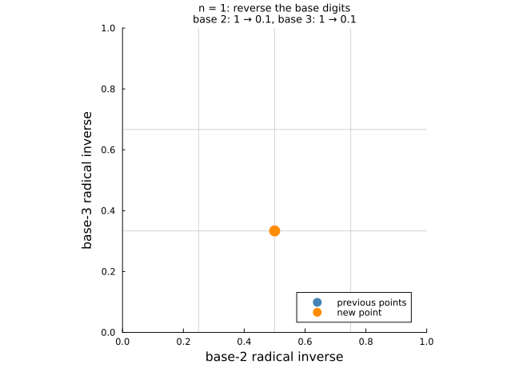

Figure 3: A two-dimensional Halton sequence reverses the digits of each index in bases 2 and 3. The newest point is orange.

```julia
halton_uniform = vec(
    QuasiMonteCarlo.sample(
        1_000,
        [0.0],
        [1.0],
        HaltonSample(),
    ),
)
halton_draws = quantile.(Ref(standard_normal), halton_uniform)
nothing
```

```julia
halton_expectation(θ) =
    mean(expectation_integrand.(θ, halton_draws))

@show halton_expectation(evaluation_parameter)
nothing
```

```
halton_expectation(evaluation_parameter) = 1.3141204576832974
```

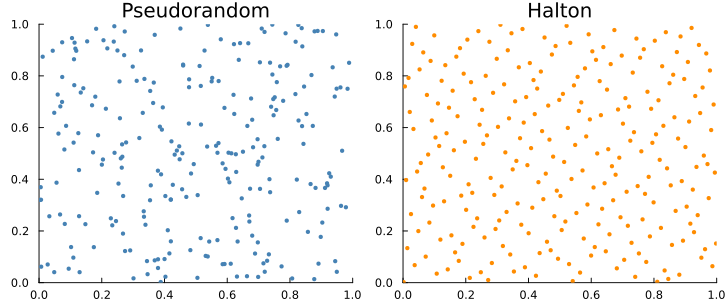

Figure 4: Halton points cover the unit square more evenly than one pseudorandom sample.

- An ordinary i.i.d. Monte Carlo standard error does not apply to a deterministic Halton sequence.

### Comparing the Methods

- No method is best for every problem. Compare the methods on the same expectation before applying the decision rules below.
- Here, every approximation is compared with the analytical value at the same parameter.

```julia
integration_methods = [
    "QuadGK" => quadgk_expectation,
    "Gauss–Hermite" => gauss_hermite_expectation,
    "Monte Carlo" => mc_expectation,
    "Halton" => halton_expectation,
]

exact_value = exact_expectation(evaluation_parameter)

method_names = first.(integration_methods)
method_estimates = [
    method(evaluation_parameter)
    for method in last.(integration_methods)
]
method_errors = abs.(method_estimates .- exact_value)

integration_comparison = DataFrame(
    "Method" => method_names,
    "Estimate" => round.(method_estimates; sigdigits = 8),
    "Exact value" => fill(
        round(exact_value; sigdigits = 8),
        length(integration_methods),
    ),
    "Absolute error" => round.(method_errors; sigdigits = 4),
)

integration_comparison
```

4×4 DataFrame

| Row | Method String | Estimate Float64 | Exact value Float64 | Absolute error Float64 |
| --- | --- | --- | --- | --- |
| 1 | QuadGK | 1.32478 | 1.32478 | 1.266e-14 |
| 2 | Gauss–Hermite | 1.32478 | 1.32478 | 1.177e-9 |
| 3 | Monte Carlo | 1.28891 | 1.32478 | 0.03588 |
| 4 | Halton | 1.31412 | 1.32478 | 0.01066 |

- The Monte Carlo result depends on the realized sample. This comparison is a diagnostic, not a general ranking.

| Method | Useful starting point | Main limitation |
| --- | --- | --- |
| Trapezoid | Geometric intuition or values on a fixed grid | Slow on a coarse grid |
| QuadGK | General one-dimensional integral | Adaptive evaluation can be costly |
| Gaussian | Smooth integral with a known domain or weight | Product rules grow as $m^d$ |
| Monte Carlo | High-dimensional expectations | Slow $N^{-1/2}$ convergence |
| Quasi-Monte Carlo | Smooth transformed integrands | No ordinary i.i.d. standard error |

**Check numerical accuracy**

- Do not rely on a single numerical approximation.
- For deterministic rules, tighten the tolerance or increase the number of nodes. For Monte Carlo, report a standard error and increase the number of draws.
- Deterministic QMC has no ordinary i.i.d. standard error; increase the number of points or use independent randomizations.

## Differentiation

- Gradient-based solvers require derivatives of the numerical objective.
- This section uses finite differences to explain numerical derivative error and forward-mode automatic differentiation for routine implementation.

### Finite Differences

- An analytical derivative is an ideal benchmark, but it may be inconvenient for a long numerical objective. Nearby function values provide the simplest numerical approximation.
- **Overview:** Finite differences are introduced here to explain step-size error and to provide an independent check.
- **Idea:** Approximate the local slope using function values on either side of the evaluation point.
- A central difference uses

$$f'(x)
\approx
\frac{f(x+h)-f(x-h)}{2h}.$$

- The figure below applies this formula to the running expectation:

$$Q(\theta)
=
E[\exp(\theta Z)]
=
\exp\left(\frac{\theta^2}{2}\right),
\qquad
Q'(\theta)
=
\theta\exp\left(\frac{\theta^2}{2}\right).$$

- At $\theta=0.75$, the exact derivative is

$$Q'(0.75)
=
0.75\exp\left(\frac{0.75^2}{2}\right)
\approx
0.993588569.$$

- For each step size $h$, the vertical axis reports

$$\operatorname{error}(h)
=
\left|
\frac{Q(0.75+h)-Q(0.75-h)}{2h}
-
Q'(0.75)
\right|.$$

- For example, $h=10^{-5}$ gives an estimate of $0.9935885691$ and an absolute error of approximately $5.15\times 10^{-11}$. Because the exact derivative is close to one, the absolute and relative errors have similar magnitudes in this example.
- Large steps create truncation error; very small steps amplify floating-point cancellation.

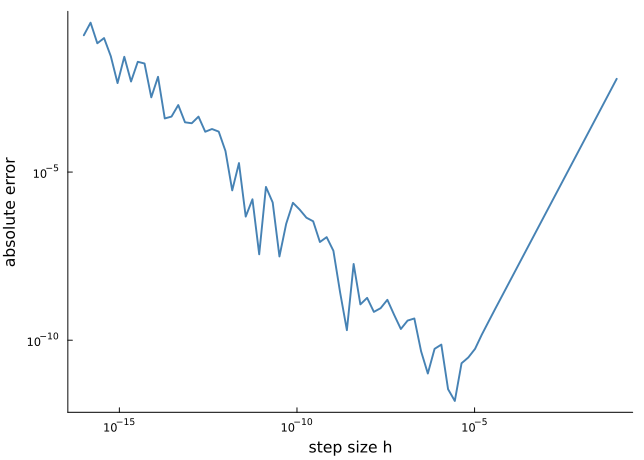

Figure 5: Absolute error when a central difference approximates Q’(0.75) ≈ 0.993588569.

- Finite differences remain useful as an independent derivative check.

### Forward-Mode Automatic Differentiation

- Finite differences require a step size and therefore face a tradeoff between truncation and floating-point error. Automatic differentiation removes that choice.
- **Overview:** Automatic differentiation computes derivatives of the executed program without perturbing its inputs.
- **Idea:** Apply the chain rule to each elementary operation in the program.
- A dual number stores the function value and derivative information together. Start with the simplest seed:

$$f(x+\epsilon)
=
f(x)+\epsilon f'(x),
\qquad
\epsilon^2=0.$$

- Here, $\epsilon$ is a formal marker, not a small real step. The ordinary component stores $f(x)$, while the coefficient of $\epsilon$ stores $f'(x)$.
- For example, if $f(x)=x^2$ and $x=3$,

$$(3+\epsilon)^2
=
9+6\epsilon.$$

- More generally, attach a seed $\dot x$ to specify the input direction:

$$f(x+\epsilon\dot x)
=
f(x)+\epsilon f'(x)\dot x.$$

- Thus, $\epsilon$ separates derivative information from the ordinary value, while $\dot x$ specifies the direction and scale of the derivative. Set $\dot x=1$ for an ordinary scalar derivative; here, $\dot x$ is a tangent seed, not a time derivative.
- [`ForwardDiff.jl`](https://juliadiff.org/ForwardDiff.jl/stable/) handles the dual-number propagation.

```julia
forward_derivative = ForwardDiff.derivative(
    exact_expectation,
    evaluation_parameter,
)

@show forward_derivative
nothing
```

```
forward_derivative = 0.993588569046649
```

| Mathematical object | `ForwardDiff` call |
| --- | --- |
| Scalar derivative | `derivative` |
| Gradient | `gradient` |
| Jacobian | `jacobian` |
| Hessian | `hessian` |

#### Forward and Reverse Modes

- Forward and reverse modes apply the same chain rule in opposite directions. Their difference is computational cost, not the derivative they return.
- Consider the scalar objective

$$y=f(x_1,x_2)
=(x_1-1)^2+2(x_2+1)^2.$$

- At $(x_1,x_2)=(0,0)$:
  - **Forward mode** first seeds the $x_1$ direction, then the $x_2$ direction, and propagates each derivative from inputs to output. Conceptually, the two directions produce $\partial y/\partial x_1=-2$ and $\partial y/\partial x_2=4$.
  - **Reverse mode** first evaluates $y$, sets the output sensitivity to $\bar y=1$, and propagates sensitivities backward through the recorded operations. One reverse pass produces both input sensitivities $(\bar x_1,\bar x_2)=(-2,4)$.

```julia
quadratic_objective(parameters) =
    (parameters[1] - 1)^2 +
    2 * (parameters[2] + 1)^2

evaluation_parameters = [0.0, 0.0]

forward_gradient = ForwardDiff.gradient(
    quadratic_objective,
    evaluation_parameters,
)
reverse_gradient = Zygote.gradient(
    quadratic_objective,
    evaluation_parameters,
)[1]

@show forward_gradient
@show reverse_gradient
nothing
```

```
forward_gradient = [-2.0, 4.0]
reverse_gradient = [-2.0, 4.0]
```

- More generally, for $f:\mathbb{R}^n\rightarrow\mathbb{R}^m$ with Jacobian $J$:
  - Forward mode propagates $Jv$ and scales mainly with the number of input directions $n$.
  - Reverse mode propagates $J^\top u$ and scales mainly with the number of output directions $m$, but it must store or recompute intermediate values.

| Mode | Prefer when | Julia backend |
| --- | --- | --- |
| Forward | Few inputs or many outputs | `ForwardDiff` |
| Reverse | Many inputs and a scalar or few outputs | `Zygote` |

- Julia usually selects the mode through the package: `ForwardDiff` uses forward mode and `Zygote` uses reverse mode. `ForwardDiff` does not have a forward-versus-reverse option.
- Forward mode remains the practical default here because the examples have one or a few parameters.

**Differentiating an Approximate Expectation**

- Hold quadrature nodes or simulation draws fixed and let AD differentiate the resulting finite approximation.
- Under standard regularity conditions and a fixed distribution, the derivative of an expectation equals the expectation of the derivative.
- AD removes finite-difference error, not integration error, and differentiates the executed program rather than the intended model.
- Nondifferentiable operations, discrete choices, branches, and nested solvers may require special treatment; check a few derivatives analytically or with finite differences.

## Parallel Computing

- Integration, simulation, and bootstrap often repeat the same computation across independent draws or samples.

### Cores, Threads, and Tasks

- Parallel computing divides work across multiple computing resources. This section focuses on CPU threads.
- A Julia thread is a worker inside one Julia process. A task is a unit of work that Julia assigns to an available thread.
- Threaded parallel execution requires more than one Julia thread.

```julia
@show Sys.CPU_THREADS
@show Threads.nthreads()
nothing
```

```
Sys.CPU_THREADS = 4
Threads.nthreads() = 4
```

- `Sys.CPU_THREADS` reports the logical CPUs available to the machine.
- `Threads.nthreads()` reports the threads available to the Julia process.
- Choose the thread count when Julia starts, for example with `julia --threads=auto`.

### Two Limits

#### Amdahl’s Law

- Let $p$ be the share of work that can run in parallel and let $P$ be the number of threads. The maximum speedup is

$$S(P)
=
\frac{1}{(1-p)+p/P}.$$

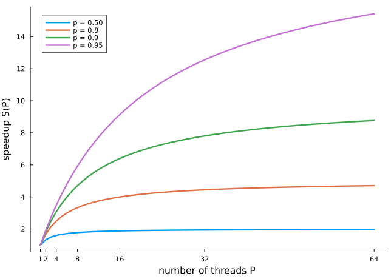

Figure 6: Amdahl’s law: speedup approaches a finite ceiling unless almost all work can run in parallel.

- If $p=0.8$, the speedup cannot exceed $1/(1-p)=5$, even with infinitely many threads.

#### Task Overhead

- Creating, scheduling, and synchronizing tasks takes time.
- Parallelization helps only when each task is large enough to cover these costs.

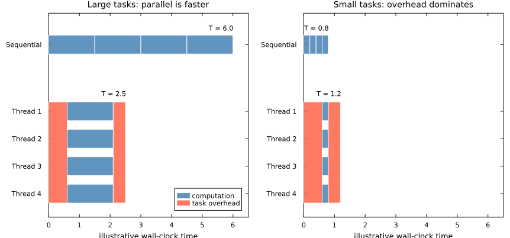

Figure 7: Task overhead can be negligible for large tasks but dominate small tasks. Both panels use the same schematic time scale.

- First-call compilation is separate from task overhead. Run the function once before timing it.

### Threads in Julia

- `Threads.@threads` distributes independent loop iterations across the available Julia threads and waits until the loop is complete.
- Iterations can run in any order, so each iteration should use its own random number generator and write to a separate output location.

#### Example: Parallel OLS Bootstrap

- Generate data from

$$y_i=\beta_0+\beta_1x_i+\varepsilon_i.$$

- Each bootstrap task resamples the observations and estimates OLS independently.

**Avoid nested parallelism**

- Matrix factorizations may already use multiple threads through a native BLAS/LAPACK library. If the outer bootstrap loop uses Julia threads, set BLAS to one thread to avoid oversubscription.
- For one large factorization, make the opposite choice: let BLAS use multiple threads and do not also split the same work with `Threads.@threads`.

```julia
function simulate_ols_data(; seed, n = 100_000)
    rng = MersenneTwister(seed)
    regressor = randn(rng, n)
    design_matrix = hcat(ones(n), regressor)
    outcome =
        design_matrix * [1.0, 2.0] +
        randn(rng, n)
    return design_matrix, outcome
end

estimate_ols(; design_matrix, outcome) =
    design_matrix \ outcome

function bootstrap_ols(; design_matrix, outcome, seed)
    rng = MersenneTwister(seed)
    sample_size = size(design_matrix, 1)
    sample_indices = rand(rng, 1:sample_size, sample_size)
    return estimate_ols(
        design_matrix = design_matrix[sample_indices, :],
        outcome = outcome[sample_indices],
    )
end

bootstrap_design, bootstrap_outcome =
    simulate_ols_data(seed = 2026)

@show size(bootstrap_design, 1)
@show size(bootstrap_design, 2)
nothing
```

```
size(bootstrap_design, 1) = 100000
size(bootstrap_design, 2) = 2
```

```julia
BLAS.set_num_threads(1)

bootstrap_repetitions = 16
bootstrap_estimates = Matrix{Float64}(
    undef,
    size(bootstrap_design, 2),
    bootstrap_repetitions,
)

Threads.@threads for repetition in 1:bootstrap_repetitions
    bootstrap_estimates[:, repetition] = bootstrap_ols(
        design_matrix = bootstrap_design,
        outcome = bootstrap_outcome,
        seed = repetition,
    )
end

bootstrap_mean = vec(mean(bootstrap_estimates; dims = 2))
bootstrap_standard_deviation =
    vec(std(bootstrap_estimates; dims = 2))

@show size(bootstrap_estimates)
@show bootstrap_mean
@show bootstrap_standard_deviation
nothing
```

```
size(bootstrap_estimates) = (2, 16)
bootstrap_mean = [0.9981003263090004, 1.99924741543754]
bootstrap_standard_deviation = [0.003059582759084851, 0.0022740259410527755]
```

### From Threads to Clusters

- Julia threads divide work within one process and one computing node.
- A cluster distributes larger jobs across processes or computing nodes.
- Divide large jobs at the cluster level and use Julia threads for smaller repeated tasks within each job.